# Framing the problem

The goal of this report is to predict the value of a house based on some independent variables. In this report, we will be using three different variables. The model used in this report for the prediction is a **univariate linear regression model**.

```python
# Importing all the necessary libraries
import pandas as pd
import matplotlib.pyplot as plt
import seaborn as sns

from sklearn import linear_model
from sklearn.metrics import mean_squared_error, mean_absolute_error
```

# Getting the data

In this report, we will use a data that pertains to the houses found in a given California district and some summary stats about them based on the 1990 census data.

The source of this data is [Carlifornia Housing Prices](https://www.kaggle.com/datasets/camnugent/california-housing-prices)

```python
housing = pd.read_csv('../data/housing.csv')
housing
```

|  | longitude | latitude | housing_median_age | total_rooms | total_bedrooms | population | households | median_income | median_house_value | ocean_proximity |
| --- | --- | --- | --- | --- | --- | --- | --- | --- | --- | --- |
| 0 | -122.23 | 37.88 | 41.0 | 880.0 | 129.0 | 322.0 | 126.0 | 8.3252 | 452600.0 | NEAR BAY |
| 1 | -122.22 | 37.86 | 21.0 | 7099.0 | 1106.0 | 2401.0 | 1138.0 | 8.3014 | 358500.0 | NEAR BAY |
| 2 | -122.24 | 37.85 | 52.0 | 1467.0 | 190.0 | 496.0 | 177.0 | 7.2574 | 352100.0 | NEAR BAY |
| 3 | -122.25 | 37.85 | 52.0 | 1274.0 | 235.0 | 558.0 | 219.0 | 5.6431 | 341300.0 | NEAR BAY |
| 4 | -122.25 | 37.85 | 52.0 | 1627.0 | 280.0 | 565.0 | 259.0 | 3.8462 | 342200.0 | NEAR BAY |
| ... | ... | ... | ... | ... | ... | ... | ... | ... | ... | ... |
| 20635 | -121.09 | 39.48 | 25.0 | 1665.0 | 374.0 | 845.0 | 330.0 | 1.5603 | 78100.0 | INLAND |
| 20636 | -121.21 | 39.49 | 18.0 | 697.0 | 150.0 | 356.0 | 114.0 | 2.5568 | 77100.0 | INLAND |
| 20637 | -121.22 | 39.43 | 17.0 | 2254.0 | 485.0 | 1007.0 | 433.0 | 1.7000 | 92300.0 | INLAND |
| 20638 | -121.32 | 39.43 | 18.0 | 1860.0 | 409.0 | 741.0 | 349.0 | 1.8672 | 84700.0 | INLAND |
| 20639 | -121.24 | 39.37 | 16.0 | 2785.0 | 616.0 | 1387.0 | 530.0 | 2.3886 | 89400.0 | INLAND |

20640 rows × 10 columns

# Exploratory Data Analysis

## Exploring and Describing the data

In this section, we are going to be looking at some info of our data.

```python
housing.describe()
```

|  | longitude | latitude | housing_median_age | total_rooms | total_bedrooms | population | households | median_income | median_house_value |
| --- | --- | --- | --- | --- | --- | --- | --- | --- | --- |
| count | 20640.000000 | 20640.000000 | 20640.000000 | 20640.000000 | 20433.000000 | 20640.000000 | 20640.000000 | 20640.000000 | 20640.000000 |
| mean | -119.569704 | 35.631861 | 28.639486 | 2635.763081 | 537.870553 | 1425.476744 | 499.539680 | 3.870671 | 206855.816909 |
| std | 2.003532 | 2.135952 | 12.585558 | 2181.615252 | 421.385070 | 1132.462122 | 382.329753 | 1.899822 | 115395.615874 |
| min | -124.350000 | 32.540000 | 1.000000 | 2.000000 | 1.000000 | 3.000000 | 1.000000 | 0.499900 | 14999.000000 |
| 25% | -121.800000 | 33.930000 | 18.000000 | 1447.750000 | 296.000000 | 787.000000 | 280.000000 | 2.563400 | 119600.000000 |
| 50% | -118.490000 | 34.260000 | 29.000000 | 2127.000000 | 435.000000 | 1166.000000 | 409.000000 | 3.534800 | 179700.000000 |
| 75% | -118.010000 | 37.710000 | 37.000000 | 3148.000000 | 647.000000 | 1725.000000 | 605.000000 | 4.743250 | 264725.000000 |
| max | -114.310000 | 41.950000 | 52.000000 | 39320.000000 | 6445.000000 | 35682.000000 | 6082.000000 | 15.000100 | 500001.000000 |

In the above table, we can see some popular statistical data about some of the columns in our dataset. We have 10 columns in total but `housing.describe()` shows us 9 columns, because the last column in not a numerical data and thus cannot perform any numerical operations on them.

As stated already, we will be focusing on:

- median income
- population
- number of households, and
- median house value

### Median Income

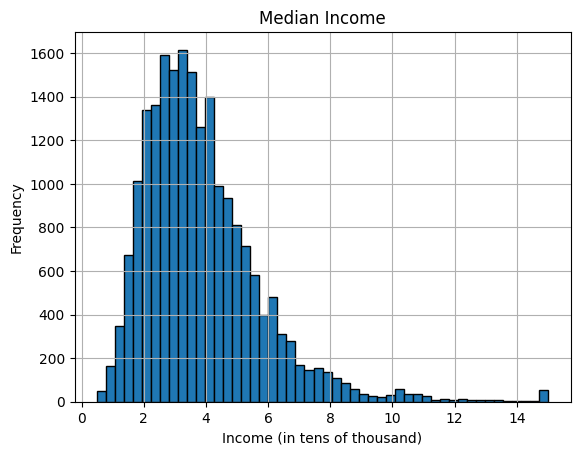

```python
housing['median_income'].hist(bins=50, edgecolor="black")
plt.title('Median Income')
plt.xlabel('Income (in tens of thousand)')
plt.ylabel('Frequency')
```

### Population

This represents the total number of people residing within a block. We have a total of 20640 rows for this variable. The values ranges from `3` people to `35,682` people. The mean value for the population is `1,425`.

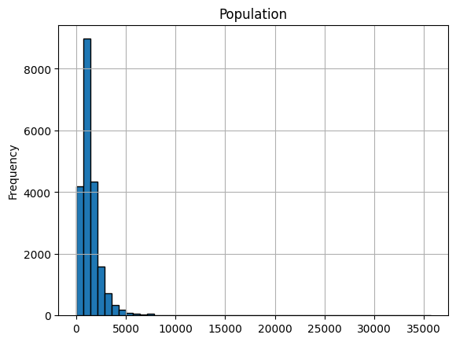

```python
housing['population'].hist(bins=50, edgecolor="black")
plt.title('Population')
plt.ylabel('Frequency')
```

### Number of Households

This is the total number of people residing within a home unit, for a block. We have a total of 20640 rows for this variable. The values ranges from `1` person up to `6082` people. The mean value for the number of people in a household is `499`.

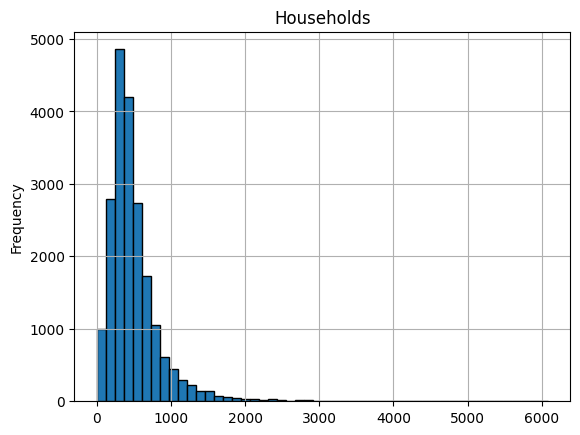

```python
housing['households'].hist(bins=50, edgecolor="black")
plt.title('Households')
plt.ylabel('Frequency')
```

### Median House Value

We have a total of 20640 rows for this variable, measured in dollars. The values ranges from `$14,999` up to `$500,000`. The mean value for the median house value is `$206,855.81`. The median house values are currently capped at `$500,000`, so we will need to handle this so it doesn't affect or skew our data.

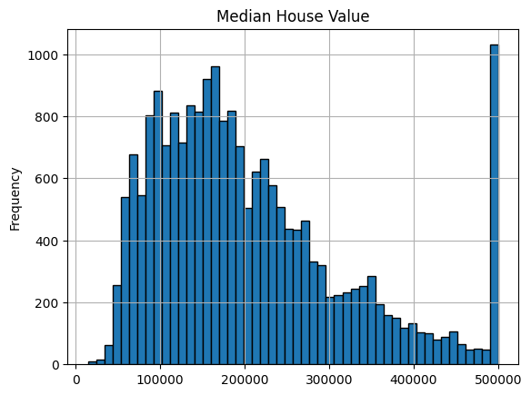

```python
housing['median_house_value'].hist(bins=50, edgecolor="black")
plt.title('Median House Value')
plt.ylabel('Frequency')
```

The capped value is very obvious now with this histogram.

### Others

We can also notice some issues in the **total_bedroms** column, as we only have 20,433 rows for this coumn. We will need to clean this up in some way.

## Visualizing the Data

### Median House Value vs Median Income

```
[Text(0.5, 1.0, 'Median House Value vs Median Income')]
```

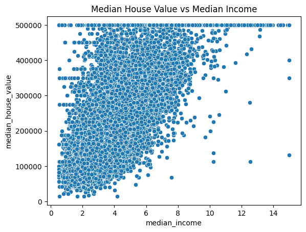

```python
sns.scatterplot(x="median_income", y="median_house_value", data=housing).set(title="Median House Value vs Median Income")
```

In this graph, I can see that there is a degree of direct variation between these two axis, as the value of the median income increases, so does the value of the house. Which makes sense, because typically, on average, the more money a household earns, the more expensive their house will be and vice versa.

We can also see how the capped house values all line up at the top of the graph, which doesn't help our visualization.

### Median House Value vs Population

```
[Text(0.5, 1.0, 'Median House Value vs Population')]
```

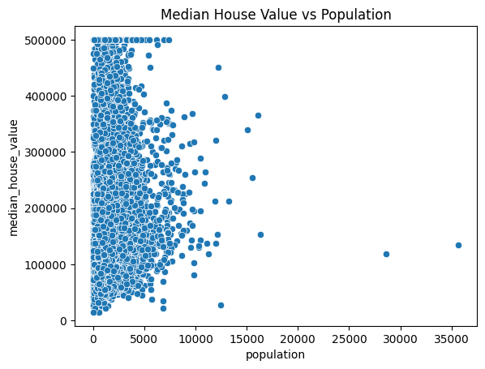

```python
sns.scatterplot(x="population", y="median_house_value", data=housing).set(title="Median House Value vs Population")
```

There is not a direct variation here, houses seem to roughly cost along different ranges irrespective of the population size. In other words, we cannot really use the population as a predictor for the value of the house.

### Median House Value vs Number of Households

```
[Text(0.5, 1.0, 'Median House Value vs Number of Households')]
```

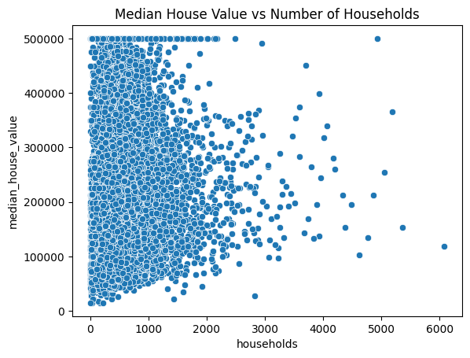

```python
sns.scatterplot(x="households", y="median_house_value", data=housing).set(title="Median House Value vs Number of Households")
```

This is not as correlated as the graph with income but it has a better spread than the one with population. In houses with more people living in them, they cost more. But then as well, there are houses with less people living in them that cost alot.

# Data Preprocessing

We will need for clean up and filter out some data that will affect our model.

Filter out records with median_house_value = 500001 since it seems to be a cap for the median_house_value.

```python
housing = housing[housing['median_house_value'] < 500001]
```

```python
print(f"We have {len(housing)} records now.")
```

```
We have 19675 records now.
```

```python
missing_data = housing.isnull().sum()
missing_data
```

```
longitude               0
latitude                0
housing_median_age      0
total_rooms             0
total_bedrooms        200
population              0
households              0
median_income           0
median_house_value      0
ocean_proximity         0
dtype: int64
```

The above code shows us that we have **200** rows that have a null value in the `total_bedrooms` column. As a good practice, it will make sense to remove these rows, even though the `total_bedrooms` column doesn't affect our projections here, but like I said, this is good, standard practice.

```python
housing = housing[housing['total_bedrooms'].notna()]
```

```python
missing_data = housing.isnull().sum()
missing_data
```

```
longitude             0
latitude              0
housing_median_age    0
total_rooms           0
total_bedrooms        0
population            0
households            0
median_income         0
median_house_value    0
ocean_proximity       0
dtype: int64
```

Now, we have no null values in our data.

```python
print(f"We now have {len(housing)} records at the end of all our preprocessing.")
```

```
We now have 19475 records at the end of all our preprocessing.
```

# Linear Regressions

## Define The Models

For this project, we will be using a **linear regression model**.

```python
income_vs_house_value_model = linear_model.LinearRegression()
population_vs_house_value_model = linear_model.LinearRegression()
household_vs_house_value_model = linear_model.LinearRegression()
```

## Train and Test Split

**Split the data into training/testing sets. Use the first 80% of the data for training.**

```python
train_size = int(len(housing) * 0.8)
train = housing[:train_size]
test = housing[train_size:]
print(f"We have {len(train)} records for our training dataset and {len(test)} records for the test data.")
```

```
We have 15580 records for our training dataset and 3895 records for the test data.
```

## Model for **Median House Value** vs **Median Income**

### Train the Model

```python
# fit
income_vs_house_value_model.fit(X=train[["median_income"]], y=train[["median_house_value"]])
```

```
LinearRegression()
```

### Evaluate the Model

For the Train and Test data:

- Print the slope and intercept
- Plot the regression line on top of the scatter plot of the training data
- Print the Mean Squared Error (MSE) and the Mean Absolute Error (MAE)

```python
# print coefficients
print(f"Intercept: {income_vs_house_value_model.intercept_}")
print(f"Coefficients: {income_vs_house_value_model.coef_}")
```

```
Intercept: [47925.28868853]
Coefficients: [[38789.29642761]]
```

### Print the MSE and MAE on the train set

```python
# print the MSE and MAE on the train set
print("Train set")
print(f"Mean squared error: {mean_squared_error(train[['median_house_value']], income_vs_house_value_model.predict(train[['median_income']]))}")
print(f"Mean absolute error: {mean_absolute_error(train[['median_house_value']], income_vs_house_value_model.predict(train[['median_income']]))}")
```

```
Train set
Mean squared error: 5563424109.858193
Mean absolute error: 55843.30101288548
```

### Print the MSE and MAE on the test set

```python
# print the MSE and MAE on the test set
print("Test set")
print(f"Mean squared error: {mean_squared_error(test[['median_house_value']], income_vs_house_value_model.predict(test[['median_income']]))}")
print(f"Mean absolute error: {mean_absolute_error(test[['median_house_value']], income_vs_house_value_model.predict(test[['median_income']]))}")
```

```
Test set
Mean squared error: 5793353540.719094
Mean absolute error: 59762.015448415565
```

## Model for **Median House Value** vs **Population**

### Train the Model

```python
# fit
population_vs_house_value_model.fit(X=train[["population"]], y=train[["median_house_value"]])
```

```
LinearRegression()
```

### Evaluate the Model

For the Train and Test data:

- Print the slope and intercept
- Plot the regression line on top of the scatter plot of the training data
- Print the Mean Squared Error (MSE) and the Mean Absolute Error (MAE)

```python
# print coefficients
print(f"Intercept: {population_vs_house_value_model.intercept_}")
print(f"Coefficients: {population_vs_house_value_model.coef_}")
```

```
Intercept: [188119.75140449]
Coefficients: [[0.32557884]]
```

### Print the MSE and MAE on the train set

```python
# print the MSE and MAE on the train set
print("Train set")
print(f"Mean squared error: {mean_squared_error(train[['median_house_value']], population_vs_house_value_model.predict(train[['population']]))}")
print(f"Mean absolute error: {mean_absolute_error(train[['median_house_value']], population_vs_house_value_model.predict(train[['population']]))}")
```

```
Train set
Mean squared error: 9255214120.244534
Mean absolute error: 75959.84854913533
```

### Print the MSE and MAE on the test set

```python
# print the MSE and MAE on the test set
print("Test set")
print(f"Mean squared error: {mean_squared_error(test[['median_house_value']], population_vs_house_value_model.predict(test[['population']]))}")
print(f"Mean absolute error: {mean_absolute_error(test[['median_house_value']], population_vs_house_value_model.predict(test[['population']]))}")
```

```
Test set
Mean squared error: 10776685145.034594
Mean absolute error: 84832.97602903418
```

## Model for **Median House Value** vs **Number of Households**

### Train the Model

```python
# fit
household_vs_house_value_model.fit(X=train[["households"]], y=train[["median_house_value"]])
```

```
LinearRegression()
```

### Evaluate the Model

For the Train and Test data:

- Print the slope and intercept
- Plot the regression line on top of the scatter plot of the training data
- Print the Mean Squared Error (MSE) and the Mean Absolute Error (MAE)

```python
# print coefficients
print(f"Intercept: {household_vs_house_value_model.intercept_}")
print(f"Coefficients: {household_vs_house_value_model.coef_}")
```

```
Intercept: [177174.12419081]
Coefficients: [[22.63273535]]
```

### Print the MSE and MAE on the train set

```python
# print the MSE and MAE on the train set
print("Train set")
print(f"Mean squared error: {mean_squared_error(train[['median_house_value']], household_vs_house_value_model.predict(train[['households']]))}")
print(f"Mean absolute error: {mean_absolute_error(train[['median_house_value']], household_vs_house_value_model.predict(train[['households']]))}")
```

```
Train set
Mean squared error: 9175580548.123121
Mean absolute error: 75539.78242488149
```

### Print the MSE and MAE on the test set

```python
# print the MSE and MAE on the test set
print("Test set")
print(f"Mean squared error: {mean_squared_error(test[['median_house_value']], household_vs_house_value_model.predict(test[['households']]))}")
print(f"Mean absolute error: {mean_absolute_error(test[['median_house_value']], household_vs_house_value_model.predict(test[['households']]))}")
```

```
Test set
Mean squared error: 10681967072.573723
Mean absolute error: 84196.83927365007
```

# Key Points Summary

| Graph | Intercept | Slope |
| --- | --- | --- |
| Median Income vs Median House Value | **47,925.29** | **38,789.29** |
| Population vs Median House Value | **188,119.75** | **0.32** |
| Number of Households vs Median House Value | **177,174.12** | **22.63** |

| Graph | Mean Squared Error |
| --- | --- |
| Median Income vs Median House Value | **5,563,424,109.86** |
| Population vs Median House Value | **9,255,214,120.24** |
| Number of Households vs Median House Value | **9,175,580,548.12** |

| Graph | Mean Absolute Error |
| --- | --- |
| Median Income vs Median House Value | **55,843.30** |
| Population vs Median House Value | **75,959.84** |
| Number of Households vs Median House Value | **75,539.78** |

# Plotting the graphs

## Graph for Median House Value vs Median Income

### Scatter Plot, train in blue and test in red, on the same plot.

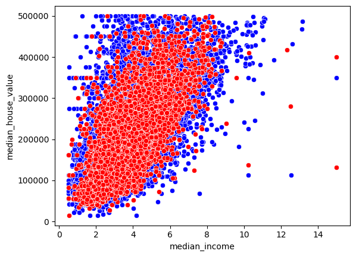

```python
sns.scatterplot(x="median_income", y="median_house_value", data=train, color="blue")
sns.scatterplot(x="median_income", y="median_house_value", data=test, color="red")
```

### Plot the regression line against the training data

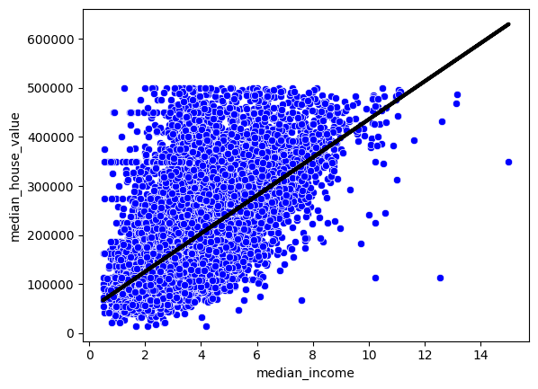

```python
sns.scatterplot(x="median_income", y="median_house_value", data=train, color="blue")
plt.plot(train[["median_income"]], income_vs_house_value_model.predict(train[["median_income"]]), color="black", linewidth=3)
```

### Plot the Regression Line against the test data

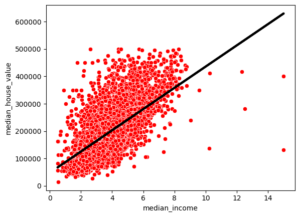

```python
sns.scatterplot(x="median_income", y="median_house_value", data=test, color="red")
plt.plot(test[["median_income"]], income_vs_house_value_model.predict(test[["median_income"]]), color="black", linewidth=3)
plt.show()
```

## Graph for Median House Value vs Population

### Scatter Plot, train in blue and test in red, on the same plot.

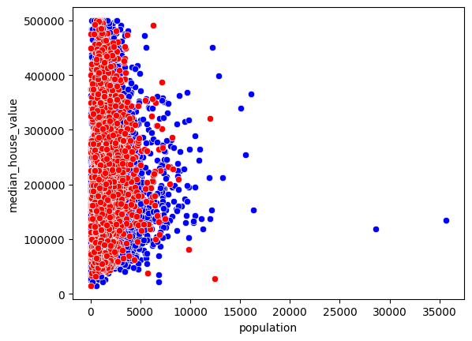

```python
sns.scatterplot(x="population", y="median_house_value", data=train, color="blue")
sns.scatterplot(x="population", y="median_house_value", data=test, color="red")
```

### Plot the regression line against the training data

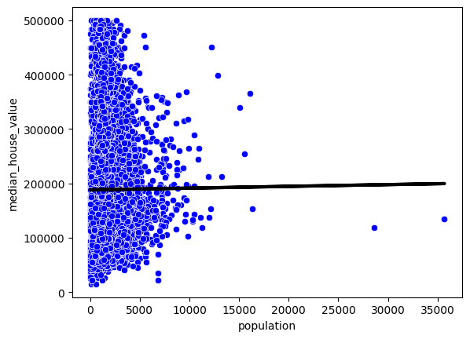

```python
sns.scatterplot(x="population", y="median_house_value", data=train, color="blue")
plt.plot(train[["population"]], population_vs_house_value_model.predict(train[["population"]]), color="black", linewidth=3)
```

### Plot the Regression Line against the test data

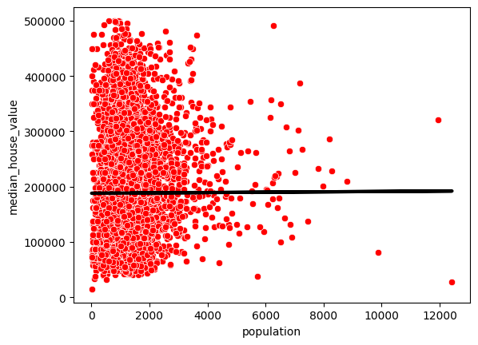

```python
sns.scatterplot(x="population", y="median_house_value", data=test, color="red")
plt.plot(test[["population"]], population_vs_house_value_model.predict(test[["population"]]), color="black", linewidth=3)
plt.show()
```

## Graph for Median House Value vs Number of Households

### Scatter Plot, train in blue and test in red, on the same plot.

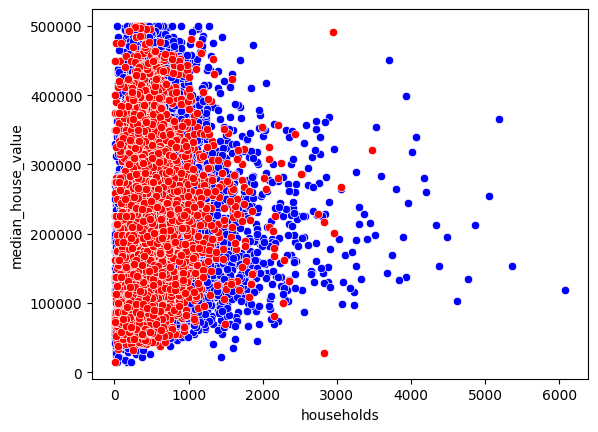

```python
sns.scatterplot(x="households", y="median_house_value", data=train, color="blue")
sns.scatterplot(x="households", y="median_house_value", data=test, color="red")
```

### Plot the regression line against the training data

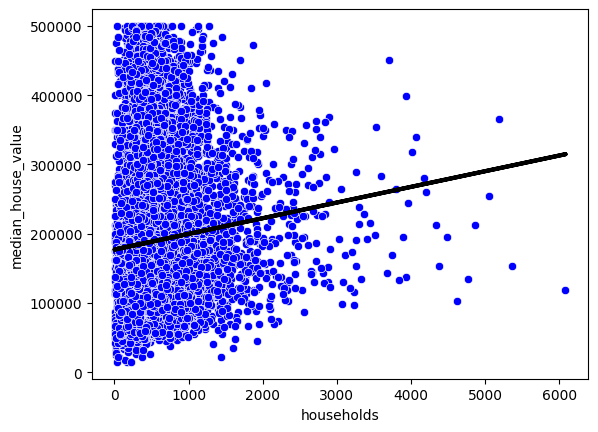

```python
sns.scatterplot(x="households", y="median_house_value", data=train, color="blue")
plt.plot(train[["households"]], household_vs_house_value_model.predict(train[["households"]]), color="black", linewidth=3)
```

### Plot the Regression Line against the test data

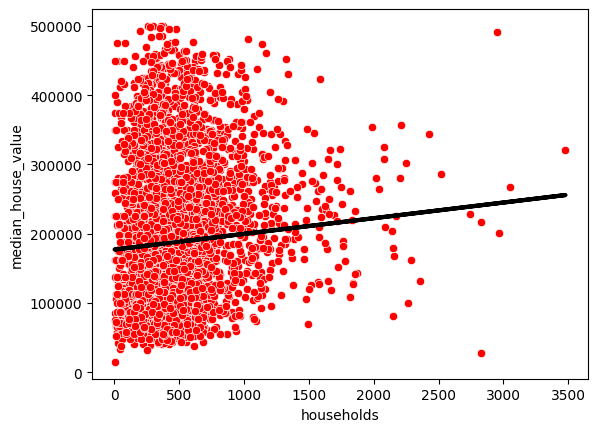

```python
sns.scatterplot(x="households", y="median_house_value", data=test, color="red")
plt.plot(test[["households"]], household_vs_house_value_model.predict(test[["households"]]), color="black", linewidth=3)
plt.show()
```

# Conclusion

The graph of median income v median house value shows nuch well our statistical model fits the observed data.

The point made above can also be seen in the table showing the intercept and the slope. A small slope indicates a flat line, while a larger value for the slope represents a more steep line.

We can also see the difference between the MSE and the MAE of each graph. The MSE is larger because we square our errors.